# Mummichog Report: data_pos_group1_before_blank_subtraction

mummichog version: 2.2.0-20200207, using metabolic model MFN_1.10.4.

## User input data

User supplied 6718 features as reference list.We are using 816 features (p < 0.050000) as significant list. The feature level data are shown in the Manhattan plots below.

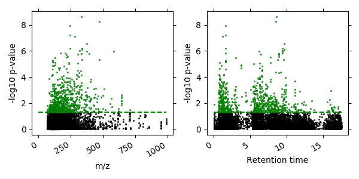

## Top pathways

The reference feature list is mapped to 530 EmpiricalCompounds, significant features to 142 EmpiricalCompounds. In the table below, pathway_size is number of detected EmpiricalCompounds for each pathway; overlap_size is number of significant EmpiricalCompounds. Empirical p-values are estimated by permutation test. Details on EmpiricalCompounds are in 'tables/ListOfEmpiricalCompounds.tsv'.

| Pathways | overlap_size | pathway_size | p-value | overlap_EmpiricalCompounds |
| --- | --- | --- | --- | --- |
| Prostaglandin formation from arachidonate | 12 | 23 | 0.00193 | E481,E1272,E1269,E936,E311,E1254,E394,E28,E1141,E346,E177,E949 |
| Arachidonic acid metabolism | 8 | 14 | 0.00445 | E481,E1272,E394,E912,E663,E346,E177,E949 |
| Leukotriene metabolism | 7 | 12 | 0.00555 | E481,E1272,E394,E663,E1041,E346,E177 |
| Butanoate metabolism | 13 | 31 | 0.01496 | E631,E645,E711,E55,E912,E914,E331,E775,E483,E946,E853,E376,E688 |
| Phosphatidylinositol phosphate metabolism | 4 | 6 | 0.01597 | E554,E19,E1080,E92 |
| Valine, leucine and isoleucine degradation | 8 | 17 | 0.01941 | E645,E775,E376,E331,E912,E483,E946,E853 |
| Pentose and Glucuronate Interconversions | 3 | 4 | 0.02084 | E1042,E781,E92 |
| Methionine and cysteine metabolism | 22 | 64 | 0.03571 | E775,E371,E177,E645,E1219,E700,E953,E722,E61,E912,E483,E1041,E586,E1220,E481,E523,E223,E785,E293,E1014,E628,E848 |
| Chondroitin sulfate degradation | 3 | 5 | 0.04512 | E1042,E781,E92 |
| Putative anti-Inflammatory metabolites formation from EPA | 3 | 5 | 0.04512 | E481,E912,E177 |
| Bile acid biosynthesis | 3 | 5 | 0.04512 | E785,E61,E953 |
| Glyoxylate and Dicarboxylate Metabolism | 3 | 5 | 0.04512 | E1042,E781,E1147 |
| Fructose and mannose metabolism | 3 | 5 | 0.04512 | E19,E1080,E1147 |
| Heparan sulfate degradation | 3 | 5 | 0.04512 | E1042,E781,E92 |
| Carbon fixation | 3 | 5 | 0.04512 | E19,E1080,E1147 |

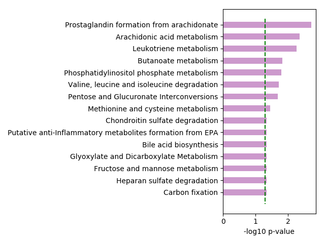

## Top modules

Network modules may capture concerted metabolite activities that are missed by predefined pathways. Use pull-down menus to visualize modules and the activity network, which tries to combine the results of pathway/module analyses. The visualization requires interenet connection.

Showing Node size Visual style

module_1, p=0.00082, 11 metabolites

D-Ribose, Spermine, Xanthine, Guanosine, Adenine, Uridine, 5-Methylthioadenosine, Deoxyadenosine, Hypoxanthine, Cytidine, Deoxycytidine

module_2, p=0.02122, 5 metabolites

Cytidine, Guanosine, Deoxyadenosine, Deoxycytidine, Uridine

## EmpiricalCompounds favored by above analyses

An EmpiricalCompound is a computational unit for a tentative metabolite. It can group multiple ions, and be any of the isobaric/isomeric species. This table contains EmpiricalCompounds prioritized by pathway/module analysis.

| EmpiricalCompound | Input m/z | Retention time | ion | mz_diff | Statistic | Significant |
| --- | --- | --- | --- | --- | --- | --- |
| E386 | Best guess: C00750, Spermine |  | C00750 |  |  |  |
|  | 203.223389161 | 0.691630701754 | M+H[1+] | 0.0004 | 2.02 | no |
|  | 203.223320347 | 1.21357017544 | M+H[1+] | 0.0003 | 1.21 | no |
|  | 102.115846395 | 0.659313541667 | M+2H[2+] | 0.0007 | 0.91 | no |
|  | 203.223136148 | 0.859380701754 | M+H[1+] | 0.0002 | 1.11 | no |
|  | 204.226674139 | 1.311253125 | M(C13)+H[1+] | 0.0003 | 0.19 | no |
|  | 102.115861995 | 1.23240098039 | M+2H[2+] | 0.0007 | 0.77 | no |
|  | 203.223307425 | 1.0837877193 | M+H[1+] | 0.0003 | 3.32 | yes |
| E912 | Best guess: C00025, L-Glutamate |  | C00217, C05938, C00025 |  |  |  |
|  | 149.064065732 | 1.03147916667 | M(C13)+H[1+] | 0.0002 | 3.73 | yes |
|  | 148.060498297 | 0.827882575758 | M+H[1+] | 0.0 | 5.15 | yes |
| E1041 | Best guess: C00302, DL-Glutamate |  | C00302 |  |  |  |
|  | 148.060498297 | 0.827882575758 | M+H[1+] | 0.0 | 5.15 | yes |
| E311 | Best guess: C02670, D-glucurono-6,3-lactone |  | glac, C00072, C02670 |  |  |  |
|  | 177.039712214 | 1.24831315789 | M+H[1+] | 0.0003 | 2.39 | yes |
|  | 199.021544456 | 1.2479 | M+Na[1+] | 0.0002 | 2.72 | yes |
| E949 | Best guess: C00639, Prostaglandin F2alpha |  | C14814, C14782, C04741, C04843, C05959, C00639 |  |  |  |
|  | 377.229635015 | 9.41967708333 | M+Na[1+] | -0.0002 | 8.21 | yes |
|  | 377.229611202 | 9.91687083333 | M+Na[1+] | -0.0003 | 3.53 | yes |
|  | 377.229847165 | 9.67635520833 | M+Na[1+] | -0.0 | 9.18 | yes |
| E523 | Best guess: C01817, |  | C01817 |  |  |  |
|  | 291.047058064 | 6.29597916667 | M+Na[1+] | 0.0027 | 3.48 | yes |
|  | 291.046958413 | 6.180621875 | M+Na[1+] | 0.0026 | 3.25 | yes |
| E1254 | Best guess: C05963, |  | C05963 |  |  |  |
|  | 393.225043296 | 8.91731458333 | M+Na[1+] | 0.0003 | 7.9 | yes |
|  | 393.224989364 | 8.722134375 | M+Na[1+] | 0.0002 | 1.73 | no |
| E1141 | Best guess: C05955, Prostaglandin C2 |  | CE5537, CE5925, CE5928, CE5535, C05953, C05957, C05954, C05955 |  |  |  |
|  | 335.2215737 | 8.905875 | M+H[1+] | -0.0001 | 7.92 | yes |
|  | 335.221648102 | 8.57083666667 | M+H[1+] | -0.0 | 13.35 | yes |
| E853 | Best guess: C02170, Methylmalonate |  | C00042, C02170 |  |  |  |

[output cut: 240 more lines]

## More data

Full data tables from pathway analysis, module analysis and activity network are stored in the 'tables/' directory. The tsv files can be imported into a spreadsheet program, e.g. MS Excel. Under the 'figures/network_modules/' directory are files intended for Cytoscape (cytoscape.org) visualization. Please refer to Cytoscape's guides for details. Details of this run are recorded in file mummichog.log.txt.